# Parte 1: Extracción y depurado de la información

## Selección de la página web

El **objetivo** de esta práctica es **extraer información** de los anuncios publicados en la página web de **Páginas Amarillas**. En esta primera sección, pedimos al usuario que interactúe con **tres campos**: por un lado, que introduzca la **categoría de búsqueda** (e.j. Restaurantes) y su **ubicación** (e.j. Alicante), y, por otro, el **número máximo de páginas** dentro del portal de anuncios de las cuales se desea extraer la información. Una vez introducidas, se almacenan en variables para su inserción en los **campos de búsqueda** del sitio web.

```python
import pandas as pd
import sys
import time
from selenium import webdriver
from webdriver_manager.chrome import ChromeDriverManager
from selenium.webdriver.common.by import By
from selenium.webdriver.common.keys import Keys
from bs4 import BeautifulSoup as bs
```

```python
sys.path.insert(0,'/usr/lib/chromium-browser/chromedriver')

# Pedimos al usuario que introduzca la categoría de búsqueda y la ubicación sobre las cuales desea almacenar información. Además, también se le pregunta sobre el número máximo de páginas.
category = input("Introduzca la categoría de búsqueda sobre la cual desea almacenar información: ")
location = input("Introduzca la ubicación de la categoría de búsqueda sobre la cual desea almacenar información: ")
pages = input("Introduzca el número máximo de páginas sobre las que desea retener información. Tenga en cuenta que el tiempo de procesado por página (30 anuncios) ronda los 5 minutos: ")

# Accedemos a la página web. En nuestro caso a Páginas Amarillas, un portal del anuncios para toda clase de establecimientos
driver = webdriver.Chrome()
url = "https://www.paginasamarillas.es"
driver.get(url)

# Guardamos los campos de búsqueda para la categoría del establecimiento y su localización
category_serch = driver.find_element(By.ID, "whatInput")
location_search = driver.find_element(By.ID, "where")

# Introducimos en los campos de búsqueda la categoría y la localización a preferencia del usuario
category_serch.send_keys(category)
location_search.send_keys(location)
location_search.send_keys(Keys.ENTER)
time.sleep(5)
```

## Almacenaje de la información

En esta sección se **almacena la información disponible de cada anuncio**. En concreto, nos quedamos con el **nombre** del establecimiento, **categoría**, **actividad**, **descripción**, **servicios**, **teléfono**, **dirección**, **código postal**, **provincia**, **métodos de pago**, **redes sociales**, **información financiera**, **horario**, y **número de estrellas** a nivel de valoraciones. Para ello, vamos recorriendo con un bucle los diferentes anuncios y vamos extrayendo la información a través de los **XPath** de los elementos en el código html de la página web. La longitud del bucle la determina el número de páginas que haya seleccionado previamente el usuario.

```python
# Creamos las listas en donde almacenaremos la información que queremos extraer
local_name = []
local_category = []
local_type = []
local_descrip = []
local_service = []
local_tel = []
local_dir = []
local_cp = []
local_prov = []
local_url = []
local_price = []
local_pm = []
local_facebook = []
local_instagram = []
local_twitter = []
local_maps = []
local_finance = []
local_schedule = []
local_stars = []
```

```python
from selenium.common.exceptions import NoSuchElementException, StaleElementReferenceException

# Bucle sobre el número máximo de páginas que ha definido el usuario
for page in range(0, int(pages)):
    time.sleep(3)

    try:
        # Generamos la lista de links y de categorías de la página
        link = driver.find_elements(By.CLASS_NAME, "mas-info")
        category = driver.find_elements(By.CSS_SELECTOR, ".business-icon")

        for url, cat in zip(range(0,(len(link))), range(0,(len(category)))):
            print(url)

            # Primero obtenemos la categoría general del establecimiento de la página principal
            category = driver.find_elements(By.CSS_SELECTOR, ".business-icon")
            class_cat = category[cat].get_attribute("class")
            print(class_cat)
            local_category.append(class_cat)

            # Empezamos a acceder a los distintos anuncios de la página principal
            link = driver.find_elements(By.CLASS_NAME, "mas-info")
            link[url].click()
            time.sleep(5)

            try:
                # Nombre del establecimiento
                name = driver.find_element(By.XPATH, ".//h1[@class = 'mt-3 line-fluid']").text
                print(name)
                local_name.append(name)

            except (StaleElementReferenceException, NoSuchElementException):
                print("NULL")
                local_name.append("NULL")
                pass

            try:
                # Especialidad del establecimiento
                type = driver.find_element(By.XPATH, ".//div[@class = 'actividades p-3 ']").text
                print(type)
                local_type.append(type)

            except (StaleElementReferenceException, NoSuchElementException):
                print("NULL")
                local_type.append("NULL")
                pass

            try:
                # Descripción básica del establecimiento
                descrip = driver.find_element(By.XPATH, ".//div[@class = 'line-fluid']").text
                print(descrip)
                local_descrip.append(descrip)

            except (StaleElementReferenceException, NoSuchElementException):
                print("NULL")
                local_descrip.append("NULL")
                pass

            try:
                # Servicios del establecimiento
                service = driver.find_element(By.XPATH, ".//div[@class = 'servicios p-3 ']").text
                print(service)
                local_service.append(service)

            except (StaleElementReferenceException, NoSuchElementException):
                print("NULL")
                local_service.append("NULL")
                pass

            try:
                # Teléfono del establecimiento
                tel = driver.find_element(By.XPATH, ".//span[@class = 'telephone']").text
                print(tel)
                local_tel.append(tel)

            except (StaleElementReferenceException, NoSuchElementException):
                print("NULL")
                local_tel.append("NULL")
                pass

            try:
                # Dirección postal del establecimiento
                dir = driver.find_element(By.XPATH, ".//span[@itemprop = 'streetAddress']").text
                print(dir)
                local_dir.append(dir)

            except (StaleElementReferenceException, NoSuchElementException):
                print("NULL")
                local_dir.append("NULL")
                pass

            try:
                # Código postal del establecimiento
                cp = driver.find_element(By.XPATH, ".//span[@itemprop = 'postalCode']").text
                print(cp)
                local_cp.append(cp)

            except (StaleElementReferenceException, NoSuchElementException):
                print("NULL")
                local_cp.append("NULL")
                pass

            try:
                # Provincia del establecimiento
                prov = driver.find_element(By.XPATH, ".//span[@itemprop = 'addressLocality']").text
                print(prov)
                local_prov.append(prov)

            except (StaleElementReferenceException, NoSuchElementException):
                print("NULL")
                local_prov.append("NULL")
                pass

            try:
                # Direccion URL de la web del establecimiento
                url = driver.find_element(By.XPATH, ".//a[@class = 'sitio-web']").get_attribute("title")
                print(url)
                local_url.append(url)

            except (StaleElementReferenceException, NoSuchElementException):
                print("NULL")
                local_url.append("NULL")
                pass

            try:
                # Precio medio de los servicios del establecimiento
                price = driver.find_element(By.XPATH, ".//div[@class = 'precio-medio mt-3']").text
                print(price)
                local_price.append(price)

            except (StaleElementReferenceException, NoSuchElementException):
                print("NULL")
                local_price.append("NULL")
                pass

            try:
                # Métodos de pago del establecimiento
                pm = driver.find_element(By.XPATH, ".//ul[@class = 'l-inline m-payment-methods']").text
                print(pm)
                local_pm.append(pm)

            except (StaleElementReferenceException, NoSuchElementException):
                print("NULL")
                local_pm.append("NULL")
                pass

            try:
                # Facebook del establecimiento
                facebook = driver.find_element(By.XPATH, ".//a[@data-omniclick = 'rrss|Facebook']").get_attribute("href")
                print(facebook)
                local_facebook.append(facebook)

            except (StaleElementReferenceException, NoSuchElementException):
                print("NULL")
                local_facebook.append("NULL")
                pass

            try:
                # Instagram del establecimiento
                instagram = driver.find_element(By.XPATH, ".//a[@data-omniclick = 'rrss|Instagram']").get_attribute("href")
                print(instagram)
                local_instagram.append(instagram)

            except (StaleElementReferenceException, NoSuchElementException):
                print("NULL")
                local_instagram.append("NULL")
                pass

            try:
                # Twitter del establecimiento
                twitter = driver.find_element(By.XPATH, ".//a[@data-omniclick = 'rrss|Twitter']").get_attribute("href")
                print(twitter)
                local_twitter.append(twitter)

            except (StaleElementReferenceException, NoSuchElementException):
                print("NULL")
                local_twitter.append("NULL")
                pass

            try:
                # Google Maps del establecimiento
                maps = driver.find_element(By.XPATH, ".//a[@data-omniclick = 'rrss|Google+']").get_attribute("href")
                print(maps)
                local_maps.append(maps)

            except (StaleElementReferenceException, NoSuchElementException):
                print("NULL")
                local_maps.append("NULL")
                pass

            try:
                # Información financiera del establecimiento
                finance = driver.find_element(By.XPATH, ".//div[@class = 'axesor p-3 ']").text
                print(finance)
                local_finance.append(finance)

            except (StaleElementReferenceException, NoSuchElementException):
                print("NULL")
                local_finance.append("NULL")
                pass

            try:
                # Horario de apertura del establecimiento
                driver.find_element(By.XPATH, ".//a[@class = 'mb-3 horario-toggler']").click()
                time.sleep(3)
                schedule = driver.find_element(By.XPATH, ".//div[@id = 'horario']").text
                print(schedule)
                local_schedule.append(schedule)

            except (StaleElementReferenceException, NoSuchElementException):
                print("NULL")
                local_schedule.append("NULL")
                pass

            try:
                # Estrellas del establecimiento
                stars = driver.find_element(By.XPATH, ".//span[contains(@class, 'stars')]").get_attribute("class")
                print(stars)
                local_stars.append(stars)

            except (StaleElementReferenceException, NoSuchElementException):
                print("NULL")
                local_stars.append("NULL")
                pass

            driver.back()
            time.sleep(5)

        driver.find_element(By.XPATH, ".//i[@class = 'fa icon-flecha-derecha']").click()

    except (StaleElementReferenceException, NoSuchElementException):
        if page == 0:
            print("\nNo se encontraron más resultados para la búsqueda especificada.")
        else:
            print("\nEl número de páginas seleccionadas es superior al número máximo de páginas para su búsqueda. Ya se ha recogido toda la información disponible.")
        break
```

## Modificación de los datos y creación del dataframe

En esta sección **modificamos y depuramos** la información extraída quedándonos únicamente con lo relevante. Tras ello, introducimos los datos en un **dataframe** para su posterior inserción en la **base de datos de MySQL**.

```python
# Chequeamos la información almacenada. Tendremos que tratar la información antes de almacenarla en un dataframe
print(local_name)
print(local_category)
print(local_type)
print(local_descrip)
print(local_service)
print(local_tel)
print(local_dir)
print(local_cp)
print(local_prov)
print(local_url)
print(local_price)
print(local_pm)
print(local_facebook)
print(local_instagram)
print(local_twitter)
print(local_maps)
print(local_finance)
print(local_schedule)
print(local_stars)
```

```
['RESTAURANTE LA ALMADRABA\nAlacant/Alicante', 'Restaurante Cervecería Castell\nAlacant/Alicante', 'Entre Bambalinas\nAlacant/Alicante', 'Asador Mendoza\nAlacant/Alicante', 'Restaurante La Matanza Castellana\nAlacant/Alicante', 'Valencia Once Restaurante\nAlacant/Alicante', 'Rincon de la Amistad\nAl…
['business-icon business-icon--restaurant', 'business-icon business-icon--restaurant', 'business-icon business-icon--restaurant', 'business-icon business-icon--restaurant', 'business-icon business-icon--restaurant', 'business-icon business-icon--restaurant', 'business-icon business-icon--restaurant'…
['Actividades\nCocina marinera', 'Actividades\nRestaurantes', 'Actividades\nRestaurantes', 'Actividades\nRestaurantes', 'Actividades\nRestaurantes', 'Actividades\nCocina mediterránea', 'Actividades\nRestaurantes', 'Actividades\nCocina mediterránea', 'Actividades\nRestaurantes', 'Actividades\nCocina …
['Especialidad en calderos, arroces, pescados, mariscos, caldereta de langosta y bogavante.', 'Especialidad en todo tipo de arroces. Menú diario de Martes a Sábado.\nTodo tipo de Celebraciones, bodas, bautizos, comuniones, comidas de empresa ...\nDesde 1977 a su servicio.', 'Restaurante en Alicante.…
['Servicios\nAire acondicionado\nCafeterías/bares\nSalón privado\nTerraza/jardín\nCalefacción\nMenú para grupos\nBodega destacable\nReservas on line', 'Servicios\nParking', 'NULL', 'NULL', 'Servicios\nAire acondicionado\nCalefacción\nParking próximo', 'Servicios\nAire acondicionado\nAcceso discapaci…
['965970587', '965252434', '966962895', '966838287', '965218561', '686760311', '965248483', '965164213', '+34697755663', '965150772', '965120321', '966053282', '965125331', '+34613665669', '965213144', '965203174', '965160298', '965189637', '965018011', '965960005', '965164618', '966086191', '965260…
['Calle Virgen del Carmen, 29', 'Calle Doctor Marañón, 8 BAJO', 'Avenida Constitución, 9 LOCAL', 'Calle Fortuny, 26', 'Calle Bailén, 13 BAJO', 'Calle Valencia, 11 BAJO', 'Avenida Enrique Monsonís Domingo, 6', 'Avenida Bruselas, 9', 'Calle Monteros Ríos, 74', 'Avenida Niza, 12 LOC 21-22', 'Calle Beni…
['03138', '03005', '03002', '03009', '03001', '03012', '03013', '03540', '03012', '03540', '03005', '03540', '03005', '03010', '03001', '03001', '03540', '03113', '03002', '03114', '03016', '03008', '03016', '03540', '03003', '03002', '03001', '03008', '03005', '03114', '03112', '03007', '03003', '0…
['Alacant/Alicante', 'Alacant/Alicante', 'Alacant/Alicante', 'Alacant/Alicante', 'Alacant/Alicante', 'Alacant/Alicante', 'Alacant/Alicante', 'Alacant/Alicante', 'Alacant/Alicante', 'Alacant/Alicante', 'Alacant/Alicante', 'Alicante/Alacant', 'Alacant/Alicante', 'Alacant/Alicante', 'Alacant/Alicante',…
['http://www.restaurantelaalmadraba.es?utm_campaign=paginasamarillas&utm_source=paginasamarillas&utm_medium=referral', 'NULL', 'http://entrebambalinas.es?utm_campaign=paginasamarillas&utm_source=paginasamarillas&utm_medium=referral', 'https://www.asadormendoza.es/', 'https://www.lamatanzacastellana.…
[' Precio medio: 25,00€', ' Precio medio: 25,00€', 'NULL', 'NULL', 'NULL', 'NULL', ' Precio medio: 20,00€', ' Precio medio: 25,00€', 'NULL', ' Precio medio: 15,00€', ' Precio medio: 18,00€', 'NULL', ' Precio medio: 15,00€', 'NULL', ' Precio medio: 13,00€', ' Precio medio: 18,00€', ' Precio medio: 20…
['Master Card\nAmerican Express\nVisa', 'Master Card\n4B\nEuroseismil\nDiners Club\nVisa', 'NULL', '4B\nMaster Card\nVisa\nEuroseismil', 'Master Card\n4B\nEuroseismil\nDiners Club\nVisa', 'Master Card\nEuroseismil\nDiners Club\nVisa', 'Master Card\n4B\nEuroseismil\nVisa\nDiners Club', 'Master Card\n…
['https://www.facebook.com/RestauranteLaAlmadraba', 'https://www.facebook.com/restaurante.castell', 'NULL', 'https://www.facebook.com/Asador-Mendoza-2108651892720242/', 'https://www.facebook.com/LaMatanzaCastellana/', 'https://www.facebook.com/valenciaonce.restaurante', 'https://www.facebook.com/Res…
['NULL', 'NULL', 'NULL', 'NULL', 'https://www.instagram.com/lamatanza_alicante/', 'NULL', 'NULL', 'NULL', 'NULL', 'NULL', 'NULL', 'NULL', 'NULL', 'https://www.instagram.com/oasis.bar.2022/', 'https://www.instagram.com/bodhigreen', 'NULL', 'NULL', 'NULL', 'https://www.instagram.com/ginosristorante', …
['https://twitter.com/Rte_laAlmadraba', 'NULL', 'NULL', 'NULL', 'NULL', 'NULL', 'NULL', 'https://www.twitter.com/@LosPacosRest', 'NULL', 'https://twitter.com/restreinas', 'NULL', 'NULL', 'https://twitter.com/pizzbrunocaruso', 'NULL', 'https://www.twitter.com/Rtebodhigreen', 'NULL', 'https://twitter.…
['NULL', 'NULL', 'NULL', 'https://www.google.com/maps/place/Asador+Mendoza/@38.3747438,-0.5040315,15z/data=!4m5!3m4!1s0x0:0xfe1f256cd143bc33!8m2!3d38.3747438!4d-0.5040315', 'https://www.google.com/maps/place/Restaurante+La+Matanza+Castellana+en+Alicante,+restaurante+en+Alicante/@38.3449189,-0.484477…
['NULL', 'NULL', 'NULL', 'Información financiera y mercantil\nFecha de constitución: 13/06/2018\nForma social: SOCIEDAD LIMITADA\nActividad CNAE: Restaurantes y puestos de comidas\nRango Nº empleados: de 0 a 10\nRango de facturación: 0€ - 500.000€\nRango del capital social: 0€ - 3.500€\nInformación …
['Lunes 10:00-17:00\nMartes 10:00-17:00\nMiércoles 10:00-17:00\nJueves 10:00-17:00\nViernes 10:00-17:00\nSábado 10:00-17:00\nDomingo 10:00-17:00', 'Lunes Cerrado\nMartes 08:00-00:00\nMiércoles 08:00-00:00\nJueves 08:00-00:00\nViernes 08:00-00:00\nSábado 08:00-00:00\nDomingo 08:00-00:00', 'NULL', 'Lu…
['stars star-0 padigital', 'stars star-0 padigital', 'stars star-0 padigital', 'stars star-0 padigital', 'stars star-0 padigital', 'stars star-4 padigital', 'stars star-5 padigital', 'stars star-0 padigital', 'stars star-0 padigital', 'stars star-0 padigital', 'stars star-0 padigital', 'stars star-0…
```

```python
# Mantenemos únicamente la razón social del establecimiento con la primera letra de cada palabra en mayúscula
Nombre = [i.split('\n')[0].title() for i in local_name]

# Nos quedamos únicamente con la categoría con la primera letra de cada palabra en mayúscula
Categoría = [i.replace('-', ' ').title() for i in local_category]
Categoría = [i.split('  ')[1] for i in Categoría]

# Nos quedamos únicamente con la actividad
Actividad = [i.split('\n')[1].capitalize() for i in local_type]

# Dividiremos los servicios en cinco columnas únicamente. Los servicios que vayan más allá se eliminarán para no saturar el modelo
diccionario = {}

for i, elemento in enumerate(local_service):
    partes = elemento.split('\n')
    for j, parte in enumerate(partes):
        diccionario.setdefault(j+1, []).append(parte)
    for k in range(len(partes)+1, 7):
        diccionario.setdefault(k, []).append("NULL")

Trash = diccionario.get(1, [])
Servicio_1 = diccionario.get(2, [])
Servicio_2 = diccionario.get(3, [])
Servicio_3 = diccionario.get(4, [])
Servicio_4 = diccionario.get(5, [])
Servicio_5 = diccionario.get(6, [])

# Nos quedaremos únicamente con la cantidad monetaria en euros
Precio_medio = []
for i in local_price:
    partes = i.split(': ')
    if len(partes) > 1:
        Precio_medio.append(partes[1])
    else:
        Precio_medio.append("NULL")

# Dividiremos los métodos de pago en cinco columnas únicamente. Los métodos de pago que vayan más allá se eliminarán para no saturar el modelo
diccionario = {}

for i, elemento in enumerate(local_pm):
    partes = elemento.split('\n')
    for j, parte in enumerate(partes):
        diccionario.setdefault(j+1, []).append(parte)
    for k in range(len(partes)+1, 6):
        diccionario.setdefault(k, []).append("NULL")

Pago_1 = diccionario.get(1, [])
Pago_2 = diccionario.get(2, [])
Pago_3 = diccionario.get(3, [])
Pago_4 = diccionario.get(4, [])
Pago_5 = diccionario.get(5, [])

# Dividiremos la información financiera en seis columnas: fecha de constitución, forma social, CNAE, rango nº empleados, rango de facturación y rango del capital social
diccionario = {}

for i, elemento in enumerate(local_finance):
    partes = elemento.split('\n')
    for j, parte in enumerate(partes):
        diccionario.setdefault(j+1, []).append(parte)
    for k in range(len(partes)+1, 8):
        diccionario.setdefault(k, []).append("NULL")

Trash = diccionario.get(1, [])
F_const = diccionario.get(2, [])
F_social = diccionario.get(3, [])
CNAE = diccionario.get(4, [])
Num_empleados = diccionario.get(5, [])
Facturación = diccionario.get(6, [])
Cap_social = diccionario.get(7, [])

## Nos quedaremos únicamente con la información, no con el título
F_const = [i.split(': ')[1] if ':' in i else "NULL" if i != "NULL" else "NULL" for i in F_const]
F_social = [i.split(': ')[1].title() if ':' in i else "NULL" if i != "NULL" else "NULL" for i in F_social]
CNAE = [i.split(': ')[1] if ':' in i else "NULL" if i != "NULL" else "NULL" for i in CNAE]
Num_empleados = [i.split(': ')[1] if ':' in i else "NULL" if i != "NULL" else "NULL" for i in Num_empleados]
Facturación = [i.split(': ')[1] if ':' in i else "NULL" if i != "NULL" else "NULL" for i in Facturación]
Cap_social = [i.split(': ')[1] if ':' in i else "NULL" if i != "NULL" else "NULL" for i in Cap_social]


# Dividiremos el horario en siete columnas: Lunes, Martes, Miércoles, Jueves, Viernes, Sábado y Domingo
diccionario = {}

for i, elemento in enumerate(local_schedule):
    partes = elemento.split('\n')
    for j, parte in enumerate(partes):
        diccionario.setdefault(j+1, []).append(parte)
    for k in range(len(partes)+1, 8):
        diccionario.setdefault(k, []).append("NULL")

Lunes = diccionario.get(1, [])
Martes = diccionario.get(2, [])
Miércoles = diccionario.get(3, [])
Jueves = diccionario.get(4, [])
Viernes = diccionario.get(5, [])
Sábado = diccionario.get(6, [])
Domingo = diccionario.get(7, [])

## Nos quedaremos únicamente con la información, no con el día de la semana
for i in range(len(Lunes)):
    Lunes[i] = Lunes[i].replace('Lunes ', '')
for i in range(len(Martes)):
    Martes[i] = Martes[i].replace('Martes ', '')
for i in range(len(Miércoles)):
    Miércoles[i] = Miércoles[i].replace('Miércoles ', '')
for i in range(len(Jueves)):
    Jueves[i] = Jueves[i].replace('Jueves ', '')
for i in range(len(Viernes)):
    Viernes[i] = Viernes[i].replace('Viernes ', '')
for i in range(len(Sábado)):
    Sábado[i] = Sábado[i].replace('Sábado ', '')
for i in range(len(Domingo)):
    Domingo[i] = Domingo[i].replace('Domingo ', '')

# Mantenemos únicamente el número de estrellas
Estrellas = [i.split('-')[1] for i in local_stars]
Estrellas = [i.split(' ')[0] for i in Estrellas]
Estrellas = [i + " de 5 estrellas" for i in Estrellas]
```

```python
# Transformamos nuestra información almacenada a dataframe
df = pd.DataFrame(zip(Nombre, Categoría, Actividad, local_descrip, Servicio_1, Servicio_2, Servicio_3, Servicio_4, Servicio_5, local_tel, local_dir, local_cp, local_prov, local_url, Precio_medio,
                      Pago_1, Pago_2, Pago_3, Pago_4, Pago_5, local_facebook, local_instagram, local_twitter, local_maps, F_const, F_social, CNAE, Num_empleados, Facturación, Cap_social, Lunes,
                      Martes, Miércoles, Jueves, Viernes, Sábado, Domingo, Estrellas),
                  columns=['Nombre', 'Categoría', 'Actividad', 'Descripción', 'Servicio_1', 'Servicio_2', 'Servicio_3', 'Servicio_4', 'Servicio_5', 'Teléfono', 'Dirección', 'Código_postal', 'Provincia', 'Sitio_web', 'Precio_medio',
                           'Método_de_pago_1', 'Método_de_pago_2', 'Método_de_pago_3', 'Método_de_pago_4', 'Método_de_pago_5', 'Facebook', 'Instagram', 'Twitter', 'Google_Maps', 'Fecha_de_constitución', 'Forma_social', 'CNAE',
                           'Número_de_empleados', 'Nivel_de_facturación', 'Capital_social', 'Lunes', 'Martes', 'Miércoles', 'Jueves', 'Viernes', 'Sábado', 'Domingo', 'Número_de_estrellas'])

# Creamos adicionalmente algunas columnas ID
df['ID_Establecimiento'] = range(1, len(df) + 1)
df
```

|  | Nombre | Categoría | Actividad | Descripción | Servicio_1 | Servicio_2 | Servicio_3 | Servicio_4 | Servicio_5 | Teléfono | ... | Capital_social | Lunes | Martes | Miércoles | Jueves | Viernes | Sábado | Domingo | Número_de_estrellas | ID_Establecimiento |
| --- | --- | --- | --- | --- | --- | --- | --- | --- | --- | --- | --- | --- | --- | --- | --- | --- | --- | --- | --- | --- | --- |
| 0 | Restaurante La Almadraba | Restaurant | Cocina marinera | Especialidad en calderos, arroces, pescados, m... | Aire acondicionado | Cafeterías/bares | Salón privado | Terraza/jardín | Calefacción | 965970587 | ... | NULL | 10:00-17:00 | 10:00-17:00 | 10:00-17:00 | 10:00-17:00 | 10:00-17:00 | 10:00-17:00 | 10:00-17:00 | 0 de 5 estrellas | 1 |
| 1 | Restaurante Cervecería Castell | Restaurant | Restaurantes | Especialidad en todo tipo de arroces. Menú dia... | Parking | NULL | NULL | NULL | NULL | 965252434 | ... | NULL | Cerrado | 08:00-00:00 | 08:00-00:00 | 08:00-00:00 | 08:00-00:00 | 08:00-00:00 | 08:00-00:00 | 0 de 5 estrellas | 2 |
| 2 | Entre Bambalinas | Restaurant | Restaurantes | Restaurante en Alicante. | NULL | NULL | NULL | NULL | NULL | 966962895 | ... | NULL | NULL | NULL | NULL | NULL | NULL | NULL | NULL | 0 de 5 estrellas | 3 |
| 3 | Asador Mendoza | Restaurant | Restaurantes | Especialidad en Carnes a la Brasa y Arroces.\n... | NULL | NULL | NULL | NULL | NULL | 966838287 | ... | 0€ - 3.500€ | 07:00-00:00 | 07:00-00:00 | 07:00-00:00 | 07:00-00:00 | 07:00-00:00 | 07:00-00:00 | Cerrado | 0 de 5 estrellas | 4 |
| 4 | Restaurante La Matanza Castellana | Restaurant | Restaurantes | La Matanza Castellana, pasión por los platos t... | Aire acondicionado | Calefacción | Parking próximo | NULL | NULL | 965218561 | ... | 0€ - 3.500€ | Cerrado | 12:00-16:30 y 20:00-00:00 | 12:00-16:30 y 20:00-00:00 | 12:00-16:30 y 20:00-00:00 | 12:00-16:30 y 20:00-00:00 | 12:00-16:30 y 20:00-00:00 | 12:00-16:30 y 20:00-00:00 | 0 de 5 estrellas | 5 |
| 5 | Valencia Once Restaurante | Restaurant | Cocina mediterránea | Restaurante tradicional con una extensa carta ... | Aire acondicionado | Acceso discapacitados | NULL | NULL | NULL | 686760311 | ... | 0€ - 3.500€ | NULL | NULL | NULL | NULL | NULL | NULL | NULL | 4 de 5 estrellas | 6 |
| 6 | Rincon De La Amistad | Restaurant | Restaurantes | Disfrute de un ambiente agradable y de una com... | Aire acondicionado | Terraza/jardín | Restaurante climatizado | Menu del dia | Tarjeta de credito | 965248483 | ... | 3.500€ - 10.000€ | NULL | NULL | NULL | NULL | NULL | NULL | NULL | 5 de 5 estrellas | 7 |
| 7 | Restaurante Los Pacos | Restaurant | Cocina mediterránea | Restaurante Los Pacos: especialidades en arroc... | Menu fin de semana | Menu semanal | Menu para grupo | Sala celebracion | Reserva para grupo | 965164213 | ... | NULL | 13:30-16:30 y 20:00-00:00 | 13:30-16:30 | Cerrado | 13:30-16:30 y 20:00-00:00 | 13:30-16:30 y 20:00-00:00 | 13:30-16:30 y 20:00-00:00 | 13:30-16:30 y 20:00-00:00 | 0 de 5 estrellas | 8 |
| 8 | Restaurante Punta Cana | Restaurant | Restaurantes | Restaurante especializado en comida dominicana... | NULL | NULL | NULL | NULL | NULL | +34697755663 | ... | NULL | 08:00-00:30 | 08:00-00:30 | 08:00-00:30 | 08:00-00:30 | 08:00-00:30 | 08:00-00:30 | 08:00-00:30 | 0 de 5 estrellas | 9 |
| 9 | Restaurante Reinas | Restaurant | Cocina mediterránea | Especialistas en arroces y frituras. Atendemos... | NULL | NULL | NULL | NULL | NULL | 965150772 | ... | 0€ - 3.500€ | 11:00-16:00 y 20:00-00:00 | 11:00-16:00 y 20:00-00:00 | 11:00-16:00 y 20:00-00:00 | 11:00-16:00 y 20:00-00:00 | 11:00-16:00 y 20:00-00:00 | 11:00-16:00 y 20:00-00:00 | 11:00-16:00 y 20:00-00:00 | 0 de 5 estrellas | 10 |
| 10 | Restaurante Indio Taj-Mahal | Restaurant | Cocina hindú | Restaurante. Cocina hindú tandoori. Menú diario. | Internet wifi | Salón privado | Acceso discapacitados | Menú para grupos | Reservas on line | 965120321 | ... | NULL | 13:00-16:00 | 13:00-16:00 y 19:30-00:00 | 13:00-16:00 y 19:30-00:00 | 13:00-16:00 y 19:30-00:00 | 13:00-16:00 y 19:30-00:00 | 13:00-16:00 y 19:30-00:00 | 13:00-16:00 y 19:30-00:00 | 0 de 5 estrellas | 11 |
| 11 | C&C Agentes Cb | Restaurant | Restaurantes | Somos especialistas en RESTAURANTES y consegui... | NULL | NULL | NULL | NULL | NULL | 966053282 | ... | NULL | NULL | NULL | NULL | NULL | NULL | NULL | NULL | 0 de 5 estrellas | 12 |
| 12 | Pizzeria Caruso | Restaurant | Cocina internacional | Gastronomía de los productos del mediterráneo.... | Internet wifi | Salón privado | Menu del dia | Servicio de reserva | Restaurante climatizado | 965125331 | ... | 10.000€ - 50.000€ | 12:00-16:00 | Cerrado | 12:00-16:00 y 20:00-00:00 | 12:00-16:00 y 20:00-00:00 | 12:00-16:00 y 20:00-00:00 | 12:00-16:00 y 20:00-00:00 | 12:00-16:00 y 20:00-00:00 | 0 de 5 estrellas | 13 |
| 13 | Bar Cafetería Oasis Latinos | Restaurant | Bar restaurante | Restaurante Latino.\nTapas Españolas. Comida L... | NULL | NULL | NULL | NULL | NULL | +34613665669 | ... | NULL | 08:00-16:00 y 18:00-00:00 | 08:00-16:00 | 08:00-16:00 y 18:00-00:00 | 08:00-16:00 y 18:00-00:00 | 08:00-16:00 y 18:00-01:30 | 08:00-16:00 y 18:00-01:30 | 16:00-00:00 | 0 de 5 estrellas | 14 |
| 14 | Bodhigreen Vegetariano | Restaurant | Cocina vegetariana | Restaurante Vegetariano\nMenús Veganos\nMenús ... | NULL | NULL | NULL | NULL | NULL | 965213144 | ... | NULL | Cerrado | 12:30-16:00 y 20:00-23:30 | 12:30-16:00 y 20:00-23:30 | 12:30-16:00 y 20:00-23:30 | 12:30-16:00 y 20:00-23:30 | 12:30-16:00 y 20:00-23:30 | 12:30-16:00 y 20:00-23:30 | 0 de 5 estrellas | 15 |
| 15 | La Sastrería | Restaurant | Restaurantes | Cocina mediterránea y de mercado. | NULL | NULL | NULL | NULL | NULL | 965203174 | ... | NULL | Cerrado | 13:00-16:30 y 20:30-00:00 | 13:00-16:30 y 20:30-00:00 | 13:00-16:30 y 20:30-00:00 | 13:00-16:30 y 20:30-00:00 | 13:00-16:30 y 20:30-00:00 | 13:00-16:30 y 20:30-00:00 | 0 de 5 estrellas | 16 |
| 16 | Restaurante El Mayoral | Restaurant | Restaurantes | Arroces, mariscos, carnes, pescados.\nTerraza ... | Aire acondicionado | Terraza/jardín | Acceso discapacitados | Admisión animales domésticos | Actuación en vivo | 965160298 | ... | NULL | 09:00-01:00 | 09:00-01:00 | 09:00-01:00 | 09:00-01:00 | 09:00-01:00 | 09:00-01:00 | Cerrado | 2 de 5 estrellas | 17 |
| 17 | El Frances | Restaurant | Cocina casera | Cocina casera EL FRANCES es un negocio ubicado... | Salón privado | Zona infantil | NULL | NULL | NULL | 965189637 | ... | NULL | 06:00-22:30 | 06:00-22:30 | 06:00-22:30 | 06:00-22:30 | 06:00-22:30 | Cerrado | Cerrado | 0 de 5 estrellas | 18 |
| 18 | Ginos Ristorante | Restaurant | Cocina italiana | Cocina italiana Ginos Ristorante es un negocio... | Admite cheque restaurante | Aire acondicionado | Terraza/jardín | Acceso discapacitados | NULL | 965018011 | ... | NULL | 13:00-16:30 y 20:00-23:30 | 13:00-16:30 y 20:00-23:30 | 13:00-16:30 y 20:00-23:30 | 13:00-16:30 y 20:00-23:30 | 13:00-16:30 y 20:00-00:00 | 13:00-17:00 y 20:00-23:30 | 13:00-17:00 y 20:00-23:30 | 5 de 5 estrellas | 19 |
| 19 | Los Pescadores | Restaurant | Cocina mediterranea | Cocina mediterranea LOS PESCADORES es un negoc... | NULL | NULL | NULL | NULL | NULL | 965960005 | ... | NULL | NULL | NULL | NULL | NULL | NULL | NULL | NULL | 0 de 5 estrellas | 20 |
| 20 | Maestral | Restaurant | Cocina mediterranea | Cocina mediterranea MAESTRAL es un negocio ubi... | Aire acondicionado | Salón privado | Parking | Aparcacoches | Terraza/jardín | 965164618 | ... | más de 100.000€ | 14:00-16:30 y 21:00-00:00 | 14:00-16:30 y 21:00-00:00 | 14:00-16:30 y 21:00-00:00 | 14:00-16:30 y 21:00-00:00 | 14:00-16:30 y 21:00-00:00 | 14:00-16:30 y 21:00-00:00 | 14:00-16:30 | 3 de 5 estrellas | 21 |
| 21 | Pollos San Gabriel | Restaurant | Cocina casera | Cocina casera Pollos San Gabriel es un negocio... | NULL | NULL | NULL | NULL | NULL | 966086191 | ... | NULL | 09:00-16:00 | 09:00-16:00 | 09:00-16:00 | 09:00-16:00 | 09:00-16:00 | 09:00-16:00 | 09:00-16:00 | 0 de 5 estrellas | 22 |
| 22 | Casa Filo | Restaurant | Cocina mediterranea | Cocina mediterranea CASA FILO es un negocio ub... | Aire acondicionado | Parking | Zona infantil | Terraza/jardín | Acceso discapacitados | 965260302 | ... | 3.500€ - 10.000€ | NULL | NULL | NULL | NULL | NULL | NULL | NULL | 0 de 5 estrellas | 23 |
| 23 | La Tagliatella | Restaurant | Cocina italiana | Cocina italiana LA TAGLIATELLA es un negocio u... | NULL | NULL | NULL | NULL | NULL | 965151630 | ... | NULL | 13:30-16:00 y 20:30-00:30 | 13:30-16:00 y 20:30-00:30 | 13:30-16:00 y 20:30-00:30 | 13:30-16:00 y 20:30-00:30 | 13:30-16:00 y 20:30-00:30 | Cerrado | Cerrado | 4 de 5 estrellas | 24 |
| 24 | Mei Li Hua | Restaurant | Cocina china | Cocina china MEI LI HUA es un negocio ubicado ... | Salón privado | Servicios a domicilio | NULL | NULL | NULL | 965926115 | ... | 0€ - 3.500€ | NULL | NULL | NULL | NULL | NULL | NULL | NULL | 0 de 5 estrellas | 25 |
| 25 | La Barrita De Santa María | Restaurant | Cocina mediterranea | Cocina mediterranea La Barrita De Santa María ... | Internet wifi | Aire acondicionado | Terraza/jardín | Parking próximo | NULL | 965210556 | ... | NULL | 13:00-15:30 | 13:00-15:30 | 13:00-15:30 | 13:00-15:30 y 19:30-00:30 | 13:00-15:30 y 19:30-00:30 | 13:00-15:30 y 19:30-00:30 | 13:00-15:30 | 0 de 5 estrellas | 26 |
| 26 | Nou Manolin | Restaurant | Cocina de mercado | Cocina de mercado NOU MANOLIN es un negocio ub... | Aire acondicionado | Salón privado | Acceso discapacitados | Bodega destacable | NULL | 965200291 | ... | 50.000€ - 100.000€ | 13:00-16:30 y 20:00-23:30 | 13:00-16:30 y 20:00-23:30 | 13:00-16:30 y 20:00-23:30 | 13:00-16:30 y 20:00-23:30 | 13:00-16:30 y 20:00-23:30 | Cerrado | Cerrado | 0 de 5 estrellas | 27 |
| 27 | Emessa | Restaurant | Cocina libanesa | Cocina libanesa Emessa es un negocio ubicado e... | Internet wifi | Aire acondicionado | Admite cheque restaurante | Terraza/jardín | Acceso discapacitados | 966368105 | ... | NULL | 12:00-23:00 | Cerrado | 12:00-23:00 | 12:00-23:00 | 12:00-23:00 | 12:00-23:00 | 12:00-23:00 | 0 de 5 estrellas | 28 |
| 28 | Astorga | Restaurant | Cocina casera | Cocina casera Astorga es un negocio ubicado en... | Aire acondicionado | Terraza/jardín | Acceso discapacitados | Parking próximo | NULL | 965120552 | ... | NULL | 07:00-23:00 | 07:00-23:00 | 07:00-23:00 | 07:00-23:00 | 07:00-23:00 | 07:00-23:00 | Cerrado | 5 de 5 estrellas | 29 |
| 29 | El Plantio | Restaurant | Cocina internacional | Cocina internacional EL PLANTIO es un negocio ... | Dispone de hotel | NULL | NULL | NULL | NULL | 965189115 | ... | NULL | NULL | NULL | NULL | NULL | NULL | NULL | NULL | 0 de 5 estrellas | 30 |
| 30 | La Ereta | Restaurant | Cocina mediterranea | Cocina mediterranea LA ERETA es un negocio ubi... | Aire acondicionado | Parking | Terraza/jardín | Acceso discapacitados | Calefacción | 965143250 | ... | NULL | 14:00-15:30 y 21:00-23:00 | 14:00-17:00 | 14:00-17:00 | 14:00-17:00 y 21:00-23:00 | 14:00-17:00 y 21:00-23:00 | 14:00-17:00 y 21:00-23:00 | Cerrado | 0 de 5 estrellas | 31 |
| 31 | 7 De Julio Asador | Restaurant | Restaurantes | Restaurant 7 DE JULIO ASADOR es un negocio ubi... | Internet wifi | Aire acondicionado | Salón privado | Parking | Acceso discapacitados | 965117011 | ... | NULL | 13:30-17:30 y 20:30-00:30 | 13:30-17:30 y 20:30-00:30 | 13:30-17:30 y 20:30-00:30 | 13:30-17:30 y 20:30-00:30 | 13:30-17:30 y 20:30-00:30 | 13:30-17:30 y 20:30-00:30 | 13:30-15:30 | 0 de 5 estrellas | 32 |
| 32 | Ambassy | Restaurant | Cocina tradicional | Cocina tradicional Ambassy es un negocio ubica... | Internet wifi | Aire acondicionado | Admite cheque restaurante | Terraza/jardín | Acceso discapacitados | 965920126 | ... | NULL | 07:30-23:30 | 07:30-23:30 | 07:30-23:30 | 07:30-23:30 | 07:30-23:30 | 07:30-23:30 | Cerrado | 0 de 5 estrellas | 33 |
| 33 | Restaurante Mamma Rita | Restaurant | Cocina italiana | Cocina italiana Restaurante Mamma Rita es un n... | Aire acondicionado | Parking próximo | Servicios a domicilio | NULL | NULL | 865528001 | ... | NULL | Cerrado | 13:00-16:00 y 20:00-00:00 | 13:00-16:00 y 20:00-00:00 | 13:00-16:00 y 20:00-00:00 | 13:00-16:00 y 20:00-00:00 | 13:00-16:00 y 20:00-00:00 | 13:00-16:00 | 0 de 5 estrellas | 34 |
| 34 | Singapur Restaurante | Restaurant | Cocina china | Cocina china Singapur Restaurante es un negoci... | NULL | NULL | NULL | NULL | NULL | 965258911 | ... | NULL | NULL | NULL | NULL | NULL | NULL | NULL | NULL | 5 de 5 estrellas | 35 |
| 35 | Cactus Cantina | Restaurant | Cocina mexicana | Cocina mexicana CACTUS CANTINA es un negocio u... | Internet wifi | Admite cheque restaurante | Menú para grupos | NULL | NULL | 965155263 | ... | 3.500€ - 10.000€ | 12:00-16:00 y 20:00-00:00 | Cerrado | 12:00-16:00 y 20:00-00:00 | 12:00-16:00 y 20:00-00:00 | 12:00-16:00 y 20:00-00:00 | 12:00-16:00 y 20:00-00:00 | 12:00-16:00 y 20:00-00:00 | 2 de 5 estrellas | 36 |
| 36 | Mcdonald´S | Restaurant | Cocina rapida | Cocina rapida Mcdonald´s es un negocio ubicado... | Internet wifi | Aire acondicionado | Salón privado | Terraza/jardín | Acceso discapacitados | 965151944 | ... | NULL | 09:00-23:00 | 09:00-23:00 | 09:00-23:00 | 09:00-23:00 | 09:00-00:00 | 09:00-00:00 | 09:00-23:00 | 0 de 5 estrellas | 37 |
| 37 | El Pescador | Restaurant | Restaurantes | Restaurant El Pescador es un negocio ubicado e... | NULL | NULL | NULL | NULL | NULL | 965207126 | ... | NULL | NULL | NULL | NULL | NULL | NULL | NULL | NULL | 0 de 5 estrellas | 38 |
| 38 | Parrilla Lanus | Restaurant | Cocina argentina | Cocina argentina Parrilla Lanus es un negocio ... | NULL | NULL | NULL | NULL | NULL | 965165194 | ... | 0€ - 3.500€ | NULL | NULL | NULL | NULL | NULL | NULL | NULL | 4 de 5 estrellas | 39 |
| 39 | El Romano | Restaurant | Cocina española | Cocina española EL ROMANO es un negocio ubicad... | NULL | NULL | NULL | NULL | NULL | 965258545 | ... | 50.000€ - 100.000€ | 09:00-11:00 | 09:00-11:00 | 09:00-11:00 | 09:00-11:00 | 09:00-11:00 | 09:00-11:00 | 09:00-11:00 | 0 de 5 estrellas | 40 |
| 40 | Aroma Pizzeria | Restaurant | Cocina italiana | Cocina italiana AROMA PIZZERIA es un negocio u... | NULL | NULL | NULL | NULL | NULL | 965202405 | ... | NULL | 13:00-24:00 | 13:00-24:00 | 13:00-24:00 | 13:00-24:00 | 13:00-24:00 | Cerrado | Cerrado | 0 de 5 estrellas | 41 |
| 41 | Juliofer S.L. | Restaurant | Restaurantes | Restaurant Juliofer S.L. es un negocio ubicado... | NULL | NULL | NULL | NULL | NULL | 965946387 | ... | NULL | NULL | NULL | NULL | NULL | NULL | NULL | NULL | 0 de 5 estrellas | 42 |
| 42 | Los Granadinos | Restaurant | Cocina casera | Cocina casera Los Granadinos es un negocio ubi... | Aire acondicionado | NULL | NULL | NULL | NULL | 965189604 | ... | NULL | NULL | NULL | NULL | NULL | NULL | NULL | NULL | 0 de 5 estrellas | 43 |
| 43 | La Serna Restaurant | Restaurant | Cocina casera | Cocina casera La Serna Restaurant es un negoci... | Internet wifi | Aire acondicionado | Parking | Menu para grupos | Reservas on line | 965286182 | ... | NULL | 11:00-15:00 y 18:00-22:00 | 11:00-15:00 y 18:00-22:00 | 11:00-15:00 y 18:00-22:00 | 11:00-15:00 y 18:00-22:00 | 11:00-15:00 y 18:00-22:00 | 09:00-14:00 | Cerrado | 0 de 5 estrellas | 44 |
| 44 | Sal Y Pimienta | Restaurant | Cocina casera | Cocina casera Sal Y Pimienta es un negocio ubi... | NULL | NULL | NULL | NULL | NULL | 966085636 | ... | NULL | 09:00-17:00 | 09:00-17:00 | 09:00-17:00 | 09:00-17:00 | 09:00-17:00 | Cerrado | Cerrado | 0 de 5 estrellas | 45 |
| 45 | Sport´S Café | Restaurant | Cocina norteamericana | Cocina norteamericana SPORT´S CAFÉ es un negoc... | Internet wifi | Aire acondicionado | Terraza/jardín | Acceso discapacitados | Menu para grupos | 966145822 | ... | NULL | 08:00-00:00 | 08:00-00:00 | 08:00-00:00 | 08:00-00:00 | 08:00-00:00 | 08:00-00:00 | 08:00-00:00 | 0 de 5 estrellas | 46 |
| 46 | Chapeau | Restaurant | Cerveceria restaurante | Cerveceria restaurante Chapeau es un negocio u... | NULL | NULL | NULL | NULL | NULL | 965922448 | ... | NULL | 10:30-24:00 | 10:30-24:00 | 10:30-24:00 | 10:30-24:00 | 10:30-24:00 | Cerrado | Cerrado | 0 de 5 estrellas | 47 |
| 47 | Burger King | Restaurant | Cocina rapida | Cocina rapida Burger King es un negocio ubicad... | NULL | NULL | NULL | NULL | NULL | 965798140 | ... | NULL | NULL | NULL | NULL | NULL | NULL | NULL | NULL | 0 de 5 estrellas | 48 |
| 48 | Salomcris S.L. | Restaurant | Bar restaurante | Bar restaurante SALOMCRIS S.L. es un negocio u... | NULL | NULL | NULL | NULL | NULL | 965288149 | ... | 0€ - 3.500€ | NULL | NULL | NULL | NULL | NULL | NULL | NULL | 0 de 5 estrellas | 49 |
| 49 | Atalayas | Restaurant | Cocina casera | Cocina casera ATALAYAS es un negocio ubicado e... | Internet wifi | Admite cheque restaurante | Aire acondicionado | Salón privado | Terraza/jardín | 615970192 | ... | NULL | 05:00-21:00 | 05:00-21:00 | 05:00-21:00 | 05:00-21:00 | 05:00-21:00 | 08:00-12:00 | Cerrado | 0 de 5 estrellas | 50 |
| 50 | Restaurante Delicias Ii | Restaurant | Cocina mediterranea | Los platos caseros de toda la vida.\nSomos esp... | Bono restaurante | Comida de empresa | Reserva para grupo | Sala celebracion | Restaurante climatizado | 965925040 | ... | NULL | 09:00-16:00 | 09:00-16:00 | 09:00-16:00 | 09:00-16:00 | 09:00-00:00 | 09:00-00:00 | 09:00-16:00 | 0 de 5 estrellas | 51 |
| 51 | Lizarran | Restaurant | Cocina española | Cocina española Lizarran es un negocio ubicado... | Internet wifi | Aire acondicionado | Admite cheque restaurante | Acceso discapacitados | Menu para grupos | 965206830 | ... | 10.000€ - 50.000€ | 09:00-00:00 | 09:00-00:00 | 09:00-00:00 | 09:00-00:00 | 09:00-00:30 | 10:00-00:30 | 09:00-00:00 | 0 de 5 estrellas | 52 |
| 52 | La Traviata Rambla | Restaurant | Cocina italiana | Cocina italiana LA TRAVIATA RAMBLA es un negoc... | Admite cheque restaurante | Aire acondicionado | Salón privado | Parking | Acceso discapacitados | 965216883 | ... | NULL | 11:00-16:15 y 20:00-00:00 | 11:00-16:15 y 20:00-00:00 | 11:00-16:15 y 20:00-00:00 | 11:00-16:15 y 20:00-00:00 | 11:00-16:15 y 20:00-00:00 | 11:00-16:15 y 20:00-00:00 | 11:00-16:15 y 20:00-00:00 | 0 de 5 estrellas | 53 |
| 53 | Lovenato S.L. | Restaurant | Restaurantes | Restaurant Lovenato S.L. es un negocio ubicado... | NULL | NULL | NULL | NULL | NULL | 965141117 | ... | 0€ - 3.500€ | NULL | NULL | NULL | NULL | NULL | NULL | NULL | 0 de 5 estrellas | 54 |
| 54 | Bella Napoli | Restaurant | Cocina italiana | Cocina italiana BELLA NAPOLI es un negocio ubi... | NULL | NULL | NULL | NULL | NULL | 965240769 | ... | 0€ - 3.500€ | NULL | NULL | NULL | NULL | NULL | NULL | NULL | 4 de 5 estrellas | 55 |
| 55 | Gloria Ruso Alabi | Restaurant | Restaurantes | Restaurant GLORIA RUSO ALABI es un negocio ubi... | NULL | NULL | NULL | NULL | NULL | 965970584 | ... | NULL | NULL | NULL | NULL | NULL | NULL | NULL | NULL | 0 de 5 estrellas | 56 |
| 56 | Casa Ramos | Restaurant | Cocina marinera | Cocina marinera Casa Ramos es un negocio ubica... | Admite cheque restaurante | Terraza/jardín | Admisión animales domésticos | NULL | NULL | 965970581 | ... | NULL | NULL | NULL | NULL | NULL | NULL | NULL | NULL | 0 de 5 estrellas | 57 |
| 57 | Tabule | Restaurant | Cocina vegetariana | Cocina vegetariana TABULE es un negocio ubicad... | NULL | NULL | NULL | NULL | NULL | 965133445 | ... | NULL | NULL | NULL | NULL | NULL | NULL | NULL | NULL | 0 de 5 estrellas | 58 |
| 58 | Cactus Cantina | Restaurant | Cocina mexicana | Cocina mexicana CACTUS CANTINA es un negocio u... | Internet wifi | Admite cheque restaurante | Aire acondicionado | Calefacción | Parking próximo | 965204658 | ... | NULL | 12:00-16:00 y 20:00-00:00 | Cerrado | 12:00-16:00 y 20:00-00:00 | 12:00-16:00 y 20:00-00:00 | 12:00-16:00 y 20:00-00:00 | 12:00-16:00 y 20:00-00:00 | 12:00-16:00 y 20:00-00:00 | 0 de 5 estrellas | 59 |

59 rows × 39 columns

# Parte 2: Inserción de la información en la base de datos de MySQL

## Creación de la Base de Datos

```python
# Importamos la librería necesaria
import mysql.connector
```

```python
# Definimos la configuración de la base de datos
con = mysql.connector.connect(user = "root", password = "130599Ivan", host = "127.0.0.1")
cursor = con.cursor()
```

```python
# Creamos la base de datos "Páginas Amarillas"
cursor.execute("DROP DATABASE IF EXISTS PAGINAS_AMARILLAS;")
cursor.execute("CREATE DATABASE PAGINAS_AMARILLAS CHARACTER SET utf8mb4;")
cursor.execute("USE PAGINAS_AMARILLAS;")
```

## Creación de tablas

Tras la creación de la base de datos, comenzamos a **crear las distintas tablas**. Todas estarán **relacionadas** con la **tabla Establecimiento**, que en la que se encuentra originariamente el **ID** de cada local. En concreto, hemos creado cuatro tablas más: **Tipo_establecimiento**, **Localidad**, **Info_financiera** y **Horario**.

```python
# Tabla "Establecimiento"
cursor.execute("CREATE TABLE IF NOT EXISTS Establecimiento("
                    "`ID_Establecimiento` INT(6) NOT NULL,"
                    "Nombre VARCHAR(100) NOT NULL,"
                    "Categoría VARCHAR(100) NOT NULL,"
                    "Teléfono VARCHAR(20) NULL,"
                    "Sitio_web VARCHAR(1000) NULL,"
                    "CONSTRAINT PK_ID_Est PRIMARY KEY (ID_Establecimiento)"
               ");")
```

```python
# Tabla "Tipo_establecimiento"
cursor.execute("CREATE TABLE IF NOT EXISTS Tipo_establecimiento("
                    "ID_Establecimiento INT(6) NOT NULL,"
                    "Actividad VARCHAR(100) NOT NULL,"
                    "Descripción VARCHAR(2000) NULL,"
                    "Precio_medio VARCHAR(20) NULL,"
                    "Número_de_estrellas VARCHAR(20) NOT NULL,"
                    "Facebook VARCHAR(100) NULL,"
                    "Instagram VARCHAR(100) NULL,"
                    "Twitter VARCHAR(100) NULL,"
                    "Google_Maps VARCHAR(1000) NULL,"
                    "Servicio_1 VARCHAR(50) NULL,"
                    "Servicio_2 VARCHAR(50) NULL,"
                    "Servicio_3 VARCHAR(50) NULL,"
                    "Servicio_4 VARCHAR(50) NULL,"
                    "Servicio_5 VARCHAR(50) NULL,"
                    "Método_de_pago_1 VARCHAR(50) NULL,"
                    "Método_de_pago_2 VARCHAR(50) NULL,"
                    "Método_de_pago_3 VARCHAR(50) NULL,"
                    "Método_de_pago_4 VARCHAR(50) NULL,"
                    "Método_de_pago_5 VARCHAR(50) NULL,"
                    "CONSTRAINT PK_Tipo_ID_Est PRIMARY KEY (ID_Establecimiento),"
                    "CONSTRAINT FK_Tipo_ID_Est FOREIGN KEY (ID_Establecimiento) REFERENCES Establecimiento(ID_Establecimiento)"
               ");")
```

```python
# Tabla "Localidad"
cursor.execute("CREATE TABLE IF NOT EXISTS Localidad("
                    "ID_Establecimiento INT(6) NOT NULL,"
                    "Dirección VARCHAR(100) NULL,"
                    "Código_postal INT NULL,"
                    "Provincia VARCHAR(50) NULL,"
                    "CONSTRAINT PK_Localidad_ID_Est PRIMARY KEY (ID_Establecimiento),"
                    "CONSTRAINT FK_Localidad_ID_Est FOREIGN KEY (ID_Establecimiento) REFERENCES Establecimiento(ID_Establecimiento)"
               ");")
```

```python
# Tabla "Info_financiera"
cursor.execute("CREATE TABLE IF NOT EXISTS Info_financiera("
                    "CNAE VARCHAR(100) NULL,"
                    "ID_Establecimiento INT(6) NOT NULL,"
                    "Fecha_constitución VARCHAR(50) NULL,"
                    "Forma_social VARCHAR(100) NULL,"
                    "Capital_social VARCHAR(100) NULL,"
                    "Nivel_facturación VARCHAR(100) NULL,"
                    "Número_empleados VARCHAR(100) NULL,"
                    "CONSTRAINT PK_Financiera_ID_Est PRIMARY KEY (ID_Establecimiento),"
                    "CONSTRAINT FK_Financiera_ID_Est FOREIGN KEY (ID_Establecimiento) REFERENCES Establecimiento(ID_Establecimiento)"
               ");")
```

```python
# Tabla "Horario"
cursor.execute("CREATE TABLE IF NOT EXISTS Horario("
                    "ID_Establecimiento INT(6) NOT NULL,"
                    "H_Lunes VARCHAR(100) NULL,"
                    "H_Martes VARCHAR(100) NULL,"
                    "H_Miércoles VARCHAR(100) NULL,"
                    "H_Jueves VARCHAR(100) NULL,"
                    "H_Viernes VARCHAR(100) NULL,"
                    "H_Sábado VARCHAR(100) NULL,"
                    "H_Domingo VARCHAR(100) NULL,"
                    "CONSTRAINT PK_Horario_ID_Est PRIMARY KEY (ID_Establecimiento),"
                    "CONSTRAINT FK_Horario_ID_Est FOREIGN KEY (ID_Establecimiento) REFERENCES Establecimiento(ID_Establecimiento)"
               ");")
```

## Inserción de la información almacenada

En esta sección realizamos los **INSERT para cada una de las tablas**. Para ello, seleccionamos la **información del dataframe**, la almacenamos en **variables**, y vamos rellenando con ellas las sentencias en **lenguaje SQL**.

```python
# Inserción de datos en la tabla "Establecimiento"
for i in df.index:
    ID_Establecimiento = int(df.ID_Establecimiento[i])
    Nombre = df.Nombre[i]
    Categoría = df.Categoría[i]
    Teléfono = df.Teléfono[i]
    Sitio_web = df.Sitio_web[i]
    add_Establecimiento = ("INSERT INTO Establecimiento"
               "(ID_Establecimiento, Nombre, Categoría, Teléfono, Sitio_web) "
               "VALUES (%s, %s, %s, %s, %s)")
    data_Establecimiento = (ID_Establecimiento, Nombre, Categoría, Teléfono, Sitio_web)
    cursor.execute(add_Establecimiento, data_Establecimiento)

    con.commit()
```

```python
# Inserción de datos en la tabla "Tipo_establecimiento"
for i in df.index:
    ID_Establecimiento = int(df.ID_Establecimiento[i])
    Actividad = df.Actividad[i]
    Descripción = df.Descripción[i]
    Precio_medio = df.Precio_medio[i]
    Número_de_estrellas = df.Número_de_estrellas[i]
    Facebook = df.Facebook[i]
    Instagram = df.Instagram[i]
    Twitter = df.Twitter[i]
    Google_Maps = df.Google_Maps[i]
    Servicio_1 = df.Servicio_1[i]
    Servicio_2 = df.Servicio_2[i]
    Servicio_3 = df.Servicio_3[i]
    Servicio_4 = df.Servicio_4[i]
    Servicio_5 = df.Servicio_5[i]
    Método_de_pago_1 = df.Método_de_pago_1[i]
    Método_de_pago_2 = df.Método_de_pago_2[i]
    Método_de_pago_3 = df.Método_de_pago_3[i]
    Método_de_pago_4 = df.Método_de_pago_4[i]
    Método_de_pago_5 = df.Método_de_pago_5[i]
    add_Tipo_establecimiento = ("INSERT INTO Tipo_establecimiento"
               "(ID_Establecimiento, Actividad, Descripción, Precio_medio, Número_de_estrellas, "
               "Facebook, Instagram, Twitter, Google_Maps, Servicio_1, Servicio_2, Servicio_3, Servicio_4, Servicio_5, "
               "Método_de_pago_1, Método_de_pago_2, Método_de_pago_3, Método_de_pago_4, Método_de_pago_5) "
               "VALUES (%s, %s, %s, %s, %s, %s, %s, %s, %s, %s, %s, %s, %s, %s, %s, %s, %s, %s, %s)")
    data_Tipo_establecimiento = (ID_Establecimiento, Actividad, Descripción, Precio_medio, Número_de_estrellas,
                            Facebook, Instagram, Twitter, Google_Maps, Servicio_1, Servicio_2, Servicio_3, Servicio_4, Servicio_5,
                            Método_de_pago_1, Método_de_pago_2, Método_de_pago_3, Método_de_pago_4, Método_de_pago_5)
    cursor.execute(add_Tipo_establecimiento, data_Tipo_establecimiento)

    con.commit()
```

```python
# Inserción de datos en la tabla "Localidad"
for i in df.index:
    ID_Establecimiento = int(df.ID_Establecimiento[i])
    Dirección = df.Dirección[i]
    Código_postal = df.Código_postal[i]
    Provincia = df.Provincia[i]
    add_Localidad = ("INSERT INTO Localidad"
               "(ID_Establecimiento, Dirección, Código_postal, Provincia) "
               "VALUES (%s, %s, %s, %s)")
    data_Localidad = (ID_Establecimiento, Dirección, Código_postal, Provincia)
    cursor.execute(add_Localidad, data_Localidad)

    con.commit()
```

```python
# Inserción de datos en la tabla "Info_financiera"
for i in df.index:
    ID_Establecimiento = int(df.ID_Establecimiento[i])
    CNAE = df.CNAE[i]
    Fecha_constitución = df.Fecha_de_constitución[i]
    Forma_social = df.Forma_social[i]
    Capital_social = df.Capital_social[i]
    Nivel_facturación = df.Nivel_de_facturación[i]
    Número_empleados = df.Número_de_empleados[i]
    add_Info_financiera = ("INSERT INTO Info_financiera"
               "(ID_Establecimiento, CNAE, Fecha_constitución, Forma_social, Capital_social, Nivel_facturación, Número_empleados) "
               "VALUES (%s, %s, %s, %s, %s, %s, %s)")
    data_Info_financiera = (ID_Establecimiento, CNAE, Fecha_constitución, Forma_social, Capital_social, Nivel_facturación, Número_empleados)
    cursor.execute(add_Info_financiera, data_Info_financiera)

    con.commit()
```

```python
# Inserción de datos en la tabla "Horario"
for i in df.index:
    ID_Establecimiento = int(df.ID_Establecimiento[i])
    H_Lunes = df.Lunes[i]
    H_Martes = df.Martes[i]
    H_Miércoles = df.Miércoles[i]
    H_Jueves = df.Jueves[i]
    H_Viernes = df.Viernes[i]
    H_Sábado = df.Sábado[i]
    H_Domingo = df.Domingo[i]
    add_Horario = ("INSERT INTO Horario"
               "(ID_Establecimiento, H_Lunes, H_Martes, H_Miércoles, H_Jueves, H_Viernes, H_Sábado, H_Domingo) "
               "VALUES (%s, %s, %s, %s, %s, %s, %s, %s)")
    data_Horario = (ID_Establecimiento, H_Lunes, H_Martes, H_Miércoles, H_Jueves, H_Viernes, H_Sábado, H_Domingo)
    cursor.execute(add_Horario, data_Horario)

    con.commit()
```

# Parte 3: Cuadro de Mando sobre los datos extraidos

En esta última sección analizaremos algunos **gráficos** con la **información de la base de datos** que acabamos de crear. Para ello, extraemos a través de **consultas SELECT** las columnas de las tablas deseadas y graficamos con las librerías `matplotlib` y `seaborn`. De los anuncios hemos podido extraer **muy poca información de tipo numérico**, por lo que la mayoría de los gráficos tendrán que ser `counts` de las categorías de las distintas variables.

```python
import matplotlib.pyplot as plt
import seaborn as sns
```

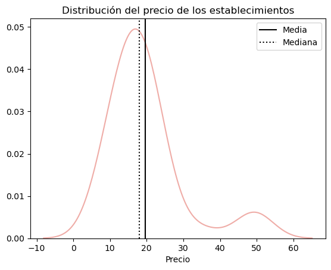

```python
# Ejecutamos una consulta SQL y almacenamos los resultados en un DataFrame
consulta = "SELECT Precio_medio FROM Tipo_establecimiento"
datos = pd.read_sql_query(consulta, con)
datos["Precio_medio"] = datos["Precio_medio"].replace("NULL", pd.np.nan)
datos = datos.dropna(subset=["Precio_medio"])
datos["Precio_medio"] = datos["Precio_medio"].str.replace("€", "")
datos["Precio_medio"] = datos["Precio_medio"].str.replace(",", ".")
datos["Precio_medio"] = datos["Precio_medio"].astype(float)

# Creamos el gráfico de densidad con líneas de media y mediana
sns.kdeplot(data=datos, x="Precio_medio", color="#EB9891", alpha=.8)
plt.axvline(x=datos["Precio_medio"].mean(), color="black", linestyle="solid", label="Media")
plt.axvline(x=datos["Precio_medio"].median(), color="black", linestyle="dotted", label="Mediana")

# Agregamos etiquetas y leyenda
plt.xlabel("Precio")
plt.ylabel(None)
plt.title("Distribución del precio de los establecimientos")
plt.ticklabel_format(style="plain", axis="both", useLocale=True)
plt.legend()

# Mostramos el gráfico
plt.show()
```

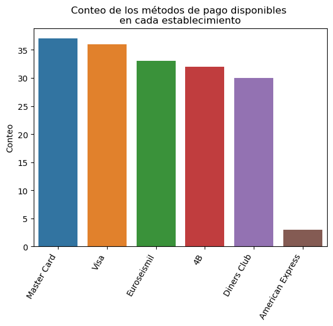

```python
# Ejecutamos una consulta SQL y almacenamos los resultados en un DataFrame
consulta = "SELECT Método_de_pago_1, Método_de_pago_2, Método_de_pago_3, Método_de_pago_4, Método_de_pago_5 FROM Tipo_establecimiento"
datos = pd.read_sql_query(consulta, con)
datos = pd.concat([datos['Método_de_pago_1'], datos['Método_de_pago_2'], datos['Método_de_pago_3'], datos['Método_de_pago_4'], datos['Método_de_pago_5']], ignore_index=True)
datos = datos.replace("NULL", pd.np.nan)
datos = datos.dropna()
datos = pd.DataFrame(datos)
datos = datos.rename(columns={0: 'Métodos'})

# Creamos el gráfico de barras
sns.countplot(x = 'Métodos', data=datos, order=datos["Métodos"].value_counts().index)
plt.xticks(rotation=60, ha="right")

# Agregamos etiquetas y leyenda
plt.title('Conteo de los métodos de pago disponibles \nen cada establecimiento')
plt.xlabel(None)
plt.ylabel('Conteo')

# Mostramos el gráfico
plt.show()
```

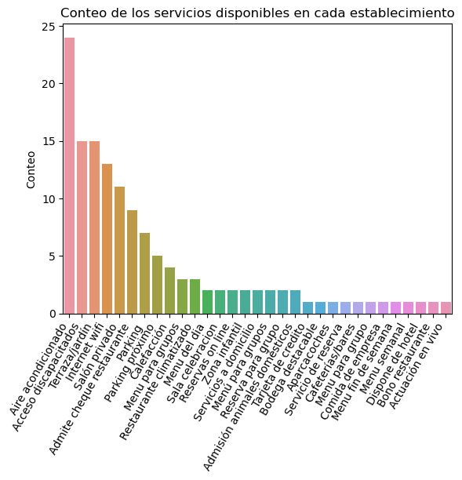

```python
# Ejecutamos una consulta SQL y almacenamos los resultados en un DataFrame
consulta = "SELECT Servicio_1, Servicio_2, Servicio_3, Servicio_4, Servicio_5 FROM Tipo_establecimiento"
datos = pd.read_sql_query(consulta, con)
datos = pd.concat([datos['Servicio_1'], datos['Servicio_2'], datos['Servicio_3'], datos['Servicio_4'], datos['Servicio_5']], ignore_index=True)
datos = datos.replace("NULL", pd.np.nan)
datos = datos.dropna()
datos = pd.DataFrame(datos)
datos = datos.rename(columns={0: 'Servicios'})

# Creamos el gráfico de barras
sns.countplot(x = 'Servicios', data=datos, order=datos["Servicios"].value_counts().index)
plt.xticks(rotation=60, ha="right")

# Agregamos etiquetas y leyenda
plt.title('Conteo de los servicios disponibles en cada establecimiento')
plt.xlabel(None)
plt.ylabel('Conteo')

# Mostramos el gráfico
plt.show()
```

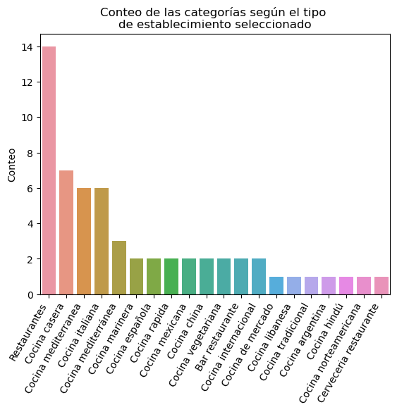

```python
# Ejecutamos una consulta SQL y almacenamos los resultados en un DataFrame
consulta = "SELECT Actividad FROM Tipo_establecimiento"
datos = pd.read_sql_query(consulta, con)
datos = datos.replace("NULL", pd.np.nan)
datos = datos.dropna()
datos = pd.DataFrame(datos)

# Creamos el gráfico de barras
sns.countplot(x = 'Actividad', data=datos, order=datos["Actividad"].value_counts().index)
plt.xticks(rotation=60, ha="right")

# Agregamos etiquetas y leyenda
plt.title('Conteo de las categorías según el tipo \nde establecimiento seleccionado')
plt.xlabel(None)
plt.ylabel('Conteo')

# Mostramos el gráfico
plt.show()
```

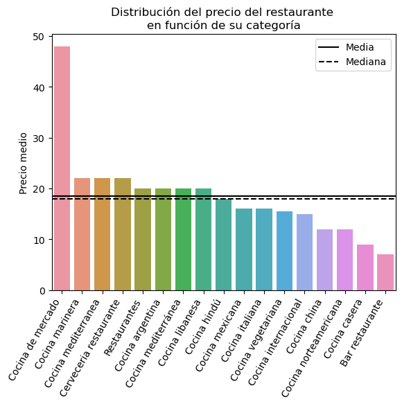

```python
# Ejecutamos una consulta SQL y almacenamos los resultados en un DataFrame
consulta = "SELECT Precio_medio, Actividad FROM Tipo_establecimiento"
datos = pd.read_sql_query(consulta, con)
datos = datos.replace("NULL", pd.np.nan)
datos = datos.dropna()
datos = pd.DataFrame(datos)
datos["Precio_medio"] = datos["Precio_medio"].str.replace("€", "")
datos["Precio_medio"] = datos["Precio_medio"].str.replace(",", ".")
datos["Precio_medio"] = datos["Precio_medio"].astype(float)
datos = datos.groupby('Actividad')['Precio_medio'].median().reset_index(name='Precio_medio')
datos['n'] = datos['Actividad'].notnull().sum()
datos_sorted = datos.sort_values('Precio_medio', ascending=False)

# Creamos el gráfico de barras con las líneas de media y mediana
sns.barplot(x='Actividad', y='Precio_medio', data=datos, order=datos_sorted['Actividad'])
plt.axhline(y=datos['Precio_medio'].mean(), color='black', linestyle='-', label='Media')
plt.axhline(y=datos['Precio_medio'].median(), color='black', linestyle='--', label='Mediana')

# Agregamos etiquetas y leyenda
plt.title('Distribución del precio del restaurante \nen función de su categoría')
plt.xlabel(None)
plt.ylabel('Precio medio')
plt.legend()
plt.xticks(rotation=60, ha="right")

# Mostramos el gráfico
plt.show()
```